# Portfolio VaR Computation

## Preliminary

Preparing the notebook by loading cool tools for the project :)

```python
conda install -c anaconda pandas-datareader
```

```
Solving environment: done

# All requested packages already installed.
```

```python
%pylab inline
import numpy as np
import pandas as pd
import pandas_datareader.data as web
import math
import scipy
import scipy.stats as stats
from scipy.stats import norm
```

We now webscrap the Data from Yahoo.

```python
Tickers = ["DPW.DE","ALV.DE","BMW.DE","BAS.DE","FME.DE"]
```

```python
# Import data from YAHOO
P = pd.DataFrame()
for t in Tickers :
    P[t] = web.DataReader(name = t, data_source = 'yahoo', start = '2017-1-1',end = '2017-12-31')['Close']

# Visualizing our data
print(" First values of the daily prices for the five stocks")
print(P.head())
print()
P.info()
```

```
 First values of the daily prices for the five stocks
               DPW.DE      ALV.DE     BMW.DE     BAS.DE     FME.DE
Date
2017-01-02  31.400000  157.300003  89.980003  88.699997  82.199997
2017-01-03  31.500000  159.550003  90.830002  87.699997  81.260002
2017-01-04  31.325001  160.399994  90.180000  88.150002  80.870003
2017-01-05  31.855000  160.699997  90.339996  87.790001  80.540001
2017-01-06  31.870001  161.100006  90.510002  87.519997  80.599998

<class 'pandas.core.frame.DataFrame'>
DatetimeIndex: 255 entries, 2017-01-02 to 2017-12-29
Data columns (total 5 columns):
DPW.DE    255 non-null float64
ALV.DE    255 non-null float64
BMW.DE    255 non-null float64
BAS.DE    255 non-null float64
FME.DE    255 non-null float64
dtypes: float64(5)
memory usage: 12.0 KB
```

## Part 1: Gaussian framework parametric method

```python
# We compute daily returns of each stock, independently
Return = pd.DataFrame()
for t in Tickers :
    Return[t] = P[t]/P[t].shift(1) - 1
Return = Return[1:]

# Define weights of each stock in the portfolio
n = len(Tickers)
weights = np.array([1/n]*n)

# Compute portfolio daily returns
Ptf_Return = Return.dot(weights)
```

```python
#Visualising the Ptf daily returns through it main stats
from scipy.stats import skew
from scipy.stats import kurtosis

print("Summary statistics")

descrip = Ptf_Return.describe()
descrip['skewnessR'] = skew(Ptf_Return)
excesskurtosisR = kurtosis(Ptf_Return)
descrip['kurtosisR'] = excesskurtosisR + 3

print(descrip)
```

```
Summary statistics
count        254.000000
mean           0.000436
std            0.007113
min           -0.017733
25%           -0.003587
50%            0.000146
75%            0.003889
max            0.033901
skewnessR      0.655793
kurtosisR      5.381146
dtype: float64
```

To compute the daily 𝑽𝒂𝑹𝟗𝟗% of 𝝅 using the Gaussian framework parametric method, we first test the normality hypothesis of the portfolio’s daily returns using Jarque Bera test.

```python
Statistic, pvalue = stats.jarque_bera(Ptf_Return)
chi2quantile = stats.chi2.ppf(0.95, df=2)

print("Here, the statistic is %f, and the p-value %f is low  (<0.05), hence such an extreme observed outcome would be very unlikely under the normality distributed assumption. " % (Statistic, pvalue))
print()
print('Let\'s still test it : ')
if(Statistic > chi2quantile): print("the Bera-Jarque test rejects at confidence level 5% the normality hypothesis")
else: print("the Bera-Jarque test do not reject at confidence level 5% the normality hypothesis ")
```

```
Here, the statistic is 78.212050, and the p-value 0.000000 is low  (<0.05), hence such an extreme observed outcome would be very unlikely under the normality distributed assumption.

Let's still test it :
the Bera-Jarque test rejects at confidence level 5% the normality hypothesis
```

Eventhough the normality hypothesis is invalidated, we shall provide a graphical analysis to (poorly) justify a Gaussian parametric method. Let's now display the histogram of the portfolio’s daily returns fitting with a normal curve.

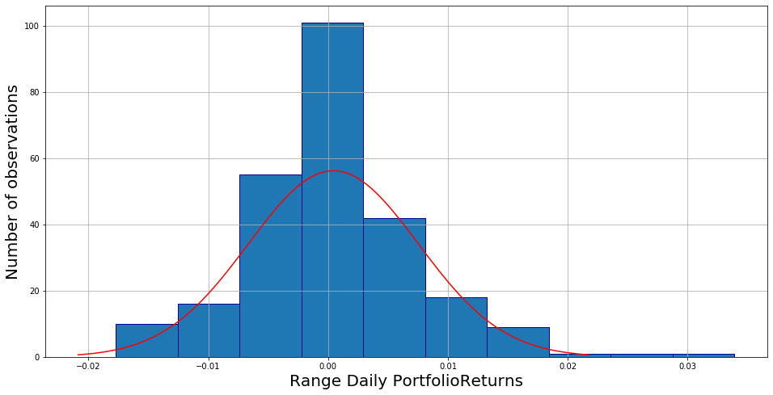

```python
# Compute normal curve estimated parameters
mean = np.mean(Ptf_Return)
sigma = np.std(Ptf_Return)

# Prepare graph
figsize(16,8) #To display large graph
x = np.linspace(mean - 3*sigma, mean + 3*sigma, 100)

# Graph
hist(Ptf_Return,edgecolor = 'darkblue', bins =10)
plot(x, scipy.stats.norm.pdf(x,mean,sigma), 'r')
grid(True)
xlabel('Range Daily PortfolioReturns', size=20)
ylabel('Number of observations', size=20)
```

We graph the QQ-plot, comparing the empirical quantiles to the theorical ones.

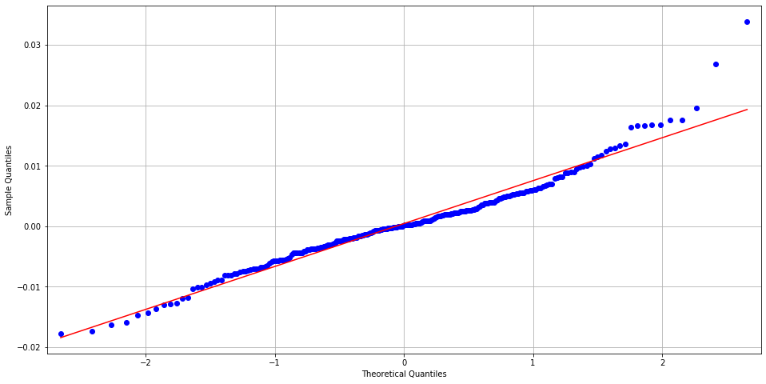

```python
import statsmodels.api as sm
sm.qqplot(Ptf_Return, line='s')
grid(True)
```

```python
#Computing the VaR99
risk = 0.01
VaR = scipy.stats.norm.ppf(risk, loc = mean, scale = sigma)*100
print("With %f percents confidence, we expect that the worst daily loss will not exceed %f percents." % (int(100*(1-risk)),round(VaR,3)))
```

```
With 99.000000 percents confidence, we expect that the worst daily loss will not exceed -1.608000 percents.
```

```python
#Compare to historical method
np.percentile(Ptf_Return, 100*risk)*100
```

```
-1.6066519591086827
```

The gaussian method slightly differs from the unparametric method, where no assumption of distribution has been made.

## Part 2: Bootstrap Historical Simulation method

Using the Bootstrap method, we compute for each new sample the 10 b-days return formula : $\prod_{i=0}^9 (R_{i,i+1} +1) - 1$

```python
#Bootstrap des données

k = 10000 #Sample size
d = 10 #Time frame

sample_ddays_return = []
for _ in range(k):

    #We prepare a sample of 10 daily returns (w replacement) and add 1 to each coordonate
    sample_n = np.random.choice(Ptf_Return, size=d) + [1]*d

    #Computation of the 10-days return for this sample
    sample_ddays_return.append(np.prod(sample_n)-1)
```

Now we've got a vector of 10000 10-business days returns, let's compute the 10 business days VaR(99).

```python
VaR_10 = np.quantile(sample_ddays_return, risk)*100
print("The 10 business days VaR99 using the Bootstrap Historical Simulation method is of %f percents, Therefore, if we invest %f dollars in this protfolio, we are %f percents confident that our worst loss over 10 b-days will not exceed %f dollars." %(round(VaR_10,3),round(100),100*(1-risk),abs(round(VaR_10,3))))
```

```
The 10 business days VaR99 using the Bootstrap Historical Simulation method is of -4.381000 percents, Therefore, if we invest 100.000000 dollars in this protfolio, we are 99.000000 percents confident that our worst loss over 10 b-days will not exceed 4.381000 dollars.
```